# Report2 - Three patch model with vaccination

Daniela Olivera

### The system

The system is three patch meta-population model. Each patch has its own disease dynamics (SIS o SIR) and is interconnected, as shown below.

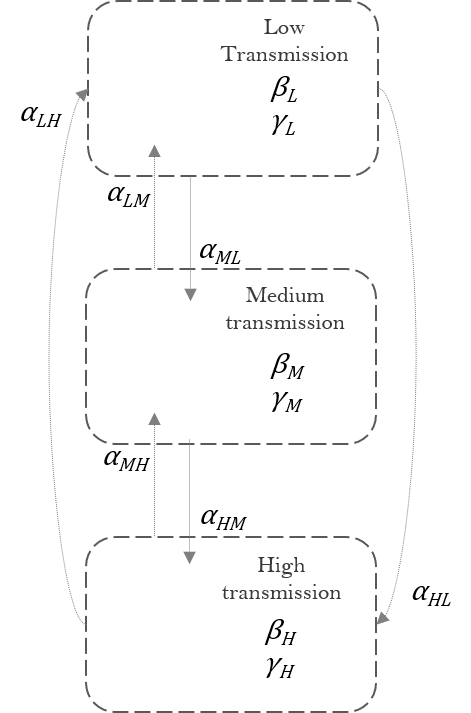

//

**Setting up the model parameters for the model:**

1. Number of patches: *npop*
2. Population in each patch: *N*
3. Individual Ro: *ro*
4. Patch recovery rate: *rec*
5. Interaction matrix between patches: Rows of the marix must sum 1
   $$\mathbf{\alpha } = \left[\begin{array}
   {rrr}
   \alpha_{LL} & \alpha_{LM} & \alpha_{LH} \\
   \alpha_{ML} & \alpha_{MM} & \alpha_{MH} \\
   \alpha_{HL} & \alpha_{HM} & \alpha_{HH}
   \end{array}\right]$$
6. Initial conditions for simulations: *I0*

```r
# General parameters for all the models
npop <- 3
N <- c(1e6, 1e6, 1e6)
rec <- c(0.5, 0.5, 0.5)
ro <- c(1.5,5,15)
alpha <-
  matrix(
    c(0.95, 0.02, 0.03, 0.02, 0.96, 0.02, 0.03, 0.02, 0.95),
    nrow = 3,
    ncol = 3,
    byrow = TRUE
  )
I0 <- c(1, 1, 1)

#Time
tt <- seq(0, 100, length.out = 201)
```

#### Basic reproductive number

The basic reproductive number is estimated using the methods described by Diekmann et al (2010) in “The construction of next-generation matrices for compartmental epidemic models”.

Both SIS and SIR models have the same differential equations for the infectous compartment, therefore their Next Generation Matrices are the same.

$$\mathbf{NGM } = \left[\begin{array}
{rrr}
\frac{\beta_L \alpha_{LL}}{\gamma_L} & \frac{\beta_L \alpha_{LM}}{\gamma_M} & \frac{\beta_L \alpha_{LH}}{\gamma_H} \\
\frac{\beta_M \alpha_{ML}}{\gamma_L} & \frac{\beta_M \alpha_{MM}}{\gamma_M} & \frac{\beta_M \alpha_{MH}}{\gamma_H} \\
\frac{\beta_H \alpha_{HL}}{\gamma_L} & \frac{\beta_H \alpha_{HM}}{\gamma_M} & \frac{\beta_H \alpha_{HH}}{\gamma_H}
\end{array}\right]$$

Using the parameters defined above the Ro value for the three patch model is **14.2547737**

**Model with vaccination**

After including vaccination on each path the next generation matrix is:

$$\mathbf{NGM } = \left[\begin{array}
{rrr}
\frac{\beta_L \alpha_{LL} (1-C_L)}{\gamma_L} & \frac{\beta_L \alpha_{LM} (1-C_L)}{\gamma_M} & \frac{\beta_L \alpha_{LH}(1-C_L)}{\gamma_H} \\
\frac{\beta_M \alpha_{ML}(1-C_M)}{\gamma_L} & \frac{\beta_M\alpha_{MM}(1-C_M)}{\gamma_M} & \frac{\beta_M \alpha_{MH}(1-C_M)}{\gamma_H} \\
\frac{\beta_H \alpha_{HL}(1-C_H)}{\gamma_L} & \frac{\beta_H \alpha_{HM}(1-C_H)}{\gamma_M} & \frac{\beta_H \alpha_{HH} (1-C_H)}{\gamma_H}
\end{array}\right]$$

Assuming the same coverage for each patch the figure below shows the change in Ro at different coverage levels.The minimun coverage required to eliminate the disease is: **0.9298481**

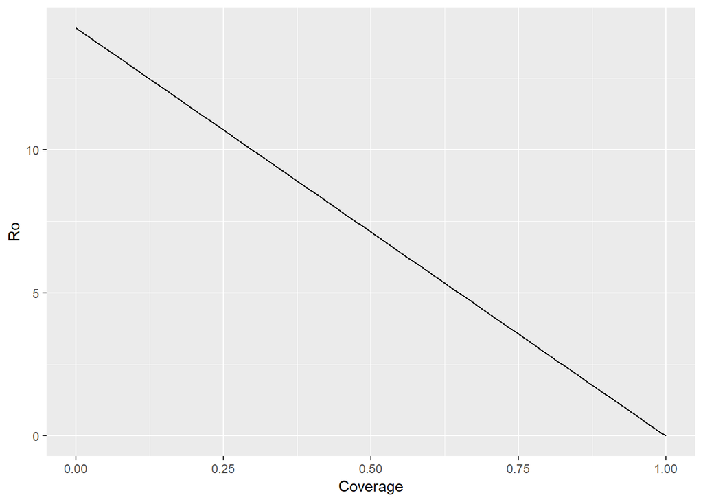

#### SIR MODEL

When the patches have a SIR disease dynamics it is possible to estimated the outbreak size or the total number of people infected during an outbreak:

```r
## ----- Basic SIR model  ---->

sir_mult <- runModel("sir_mult.R",tt,np = npop,N = N,rec = rec,ro = ro,alpha = alpha,I0 = I0)

outbreakSize <- tail(sir_mult, 1)[1, 11:13]
colnames(outbreakSize) <- c("Low transmission", "Medium transmission", "High transmission")

outbreakSize <- as.numeric (outbreakSize)
```

| Low transmission | Medium transmission | High transmision |
| --- | --- | --- |
| 6.12110^{5} | 9.92710^{5} | 10^{6}` |

**Including vaccination:**

When vaccination is included and coverages is the same for all the patches, the fraction of cases averted varies as follows

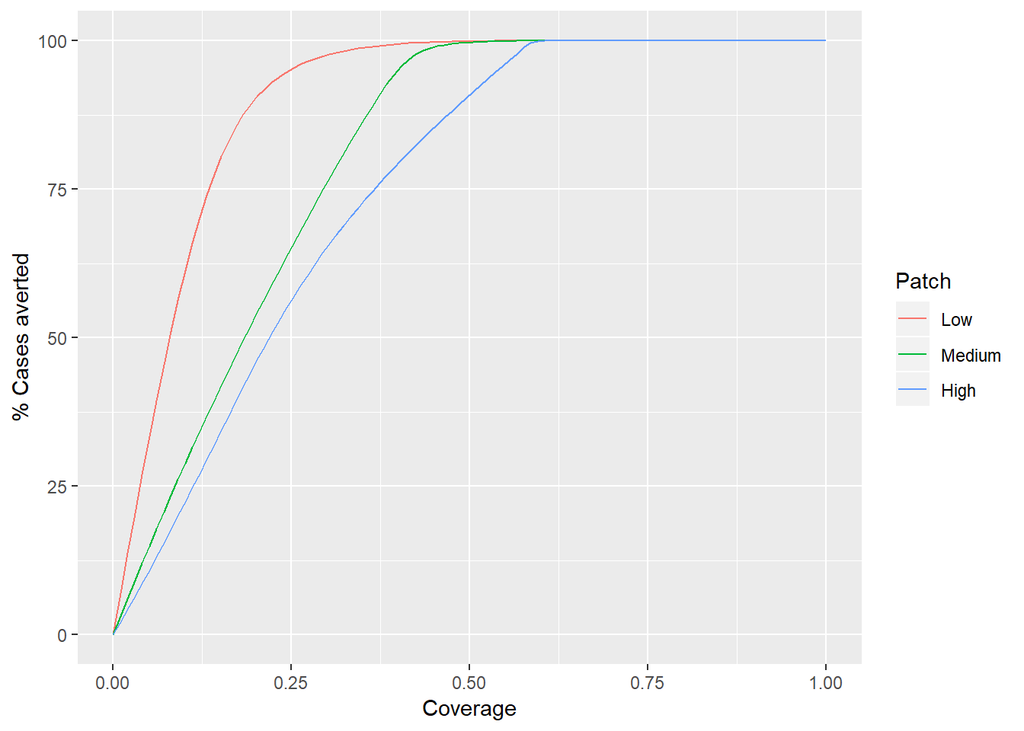

#### SIS Model

When there is a SIS disease dynamics the endemic state of the disease can be estimated:

```r
#Steady state
ss <- multiroot(f = SS_SIS, start = c(1e6, 1e6, 1e6), alpha = alpha, ro = ro, rec = rec,N = N)
endemic <- ss$root
```

| Low transmission | Medium transmission | High transmision |
| --- | --- | --- |
| 3.99710^{5} | 8.06410^{5} | 9.35310^{5} |

**Including vaccination:**

When vaccination is included with equal coverage on each patch the number of cases averted at the steady is:

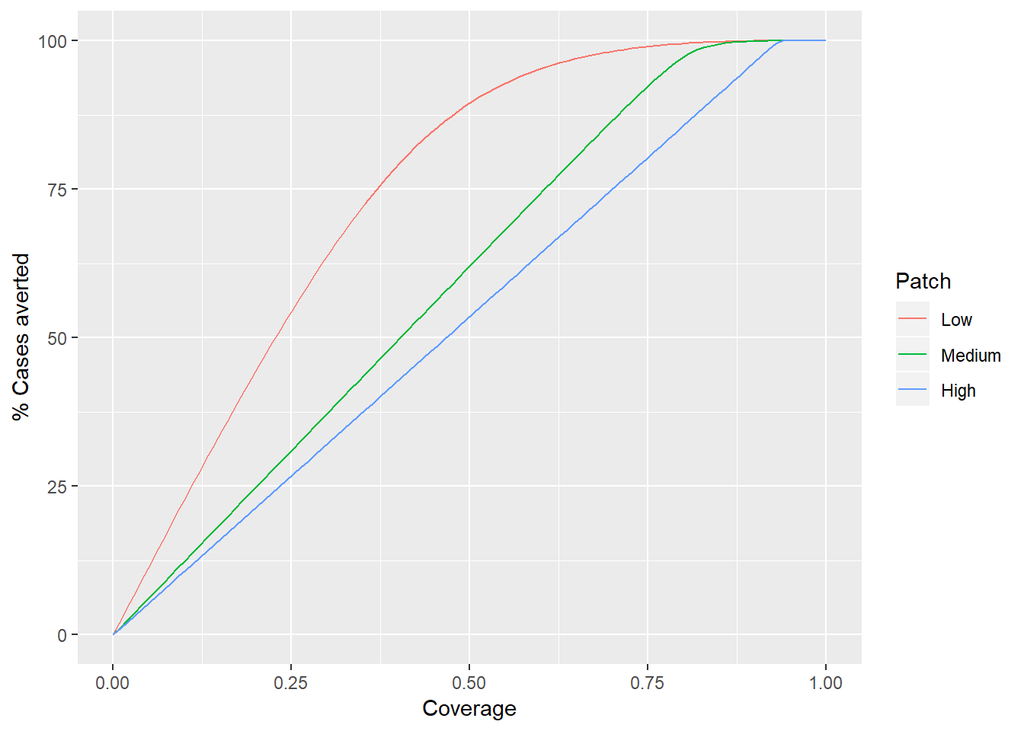

### Limited number of vaccines:

**R0**

```r
# Algorithms that work: NLOPT_LN_COBYLA - NLOPT_GN_ISRES - NLOPT_GN_DIRECT - NLOPT_GN_DIRECT_L

cov_0 <- c(0.5,0.5,0.5)
opts <- list("algorithm" = "NLOPT_GN_ISRES", "xtol_rel" = 1.0e-8)
Vmax <- 2e6

R0_min <- nloptr(x0 = cov_0,eval_f = f_min,eval_g_ineq = g_min, lb = c(0, 0, 0), ub = c(1, 1, 1), opts = opts, alpha = alpha, rec = rec,ro = ro,
    N = N, Vmax = Vmax)
```

With 210^{6} vaccines as a constraint, the table below shows the coverages required in each patch to reduce the reproductive number to 1.4056993.

*Note: The results change with each iteration*

| Low transmission | Medium transmission | High transmision |
| --- | --- | --- |
| 0.02 | 0.729 | 0.956 |

**SIS dynamics**

In the system with SIS disease dynamics the objective function maximizes the number of cases averted on the three populations

```r
min_sis <-  nloptr(x0 = cov_0,eval_f = sis_min, eval_g_ineq = g_min,lb = c(0, 0, 0),ub = c(1, 1, 1),opts = opts,alpha = alpha,rec = rec,
    ro = ro,N = N,Vmax = Vmax)
```

It is possible to avert the 87.0081317 % of the cases, with 210^{6} vaccines as a constraint, the table below shows the coverages required in each patch:

| Low transmission | Medium transmission | High transmision |
| --- | --- | --- |
| 0.067 | 0.922 | 0.959 |

**SIR dynamics**

```r
cov_0 <- c(0.5,0.5,0.5)

opts <- list("algorithm" = "NLOPT_GN_ISRES", "xtol_rel" = 1.0e-8)

min_sir <- nloptr(x0 = cov_0, eval_f = sir_min , eval_g_ineq = g_min, lb = c(0, 0, 0), ub = c(1, 1, 1), opts = opts, alpha = alpha, rec = rec,
    ro = ro,N = N,Vmax = Vmax)
```

*Note: The optimization is very sensitive to inital conditions and algorithms since ODIN may not be able to solve the system with specific coverage combinations ant the process fails*

It is possible to avert the 99.99969 % of the cases, with 210^{6} vaccines as a constraint, the table below shows the coverages required in each patch:

| Low transmission | Medium transmission | High transmision |
| --- | --- | --- |
| 0.392 | 0.6 | 0.969 |